# Lab 1: let’s know iris

# Goals

1. get `iris` data
2. know basic info about it
3. plot iris and play with it

# Possible “solution”

## Get data

`iris` is so common that it is a global variable preloaded in the R environment. Hence you can “access” it by just writing `iris`.

```r
iris
```

| Sepal.Length | Sepal.Width | Petal.Length | Petal.Width | Species |
| --- | --- | --- | --- | --- |
| 5.1 | 3.5 | 1.4 | 0.2 | setosa |
| 4.9 | 3.0 | 1.4 | 0.2 | setosa |
| 4.7 | 3.2 | 1.3 | 0.2 | setosa |
| 4.6 | 3.1 | 1.5 | 0.2 | setosa |
| 5.0 | 3.6 | 1.4 | 0.2 | setosa |
| 5.4 | 3.9 | 1.7 | 0.4 | setosa |
| 4.6 | 3.4 | 1.4 | 0.3 | setosa |
| 5.0 | 3.4 | 1.5 | 0.2 | setosa |
| 4.4 | 2.9 | 1.4 | 0.2 | setosa |
| 4.9 | 3.1 | 1.5 | 0.1 | setosa |

[output cut: 140 more lines]

In a notebook, you see the result nicely formatted. Try execute it in the console to see the “raw” result.

In a more common case, you load the data from a file or directly from the network. In the former case, you usually use `read.table` and its variants (`read.csv`, `read.csv2`).

## Basic exploration of the data

Let’s use another variable for working on `iris`: `d` stands for data.

```r
d = iris
```

Note that `d` is an identifier of a variable whose value is a “dataframe”, i.e., a table with columns with values of homogeneous type.

See its size, in three different ways.

```r
dim(d)
```

```
[1] 150   5
```

```r
nrow(d)
```

```
[1] 150
```

```r
ncol(d)
```

```
[1] 5
```

Ok, we got it: it’s a $150 \times 5$ table.

For an overview of the content, use `summary`.

```r
summary(d)
```

```
  Sepal.Length    Sepal.Width     Petal.Length    Petal.Width          Species
 Min.   :4.300   Min.   :2.000   Min.   :1.000   Min.   :0.100   setosa    :50
 1st Qu.:5.100   1st Qu.:2.800   1st Qu.:1.600   1st Qu.:0.300   versicolor:50
 Median :5.800   Median :3.000   Median :4.350   Median :1.300   virginica :50
 Mean   :5.843   Mean   :3.057   Mean   :3.758   Mean   :1.199
 3rd Qu.:6.400   3rd Qu.:3.300   3rd Qu.:5.100   3rd Qu.:1.800
 Max.   :7.900   Max.   :4.400   Max.   :6.900   Max.   :2.500
```

For each one of the numerical variables (columns) of the dataframe, basic descriptive statistics are shown; for categorical variables, the number of occurrences of each possible (actually valued) values is shown.

For just showing the names of the variables, use `names`.

```r
names(d)
```

```
[1] "Sepal.Length" "Sepal.Width"  "Petal.Length" "Petal.Width"  "Species"
```

`names` can also be used for changing the names:

```r
names(d)[2] = "sw"
summary(d)
```

```
  Sepal.Length         sw         Petal.Length    Petal.Width          Species
 Min.   :4.300   Min.   :2.000   Min.   :1.000   Min.   :0.100   setosa    :50
 1st Qu.:5.100   1st Qu.:2.800   1st Qu.:1.600   1st Qu.:0.300   versicolor:50
 Median :5.800   Median :3.000   Median :4.350   Median :1.300   virginica :50
 Mean   :5.843   Mean   :3.057   Mean   :3.758   Mean   :1.199
 3rd Qu.:6.400   3rd Qu.:3.300   3rd Qu.:5.100   3rd Qu.:1.800
 Max.   :7.900   Max.   :4.400   Max.   :6.900   Max.   :2.500
```

(Now let’s restore the original name).

```r
d = iris
names(d)
```

```
[1] "Sepal.Length" "Sepal.Width"  "Petal.Length" "Petal.Width"  "Species"
```

## Basic graphical exploration

`plot` is an R function that can be used to plot almost everything. It is an example of polymorphism: its behavior changes depending on what it is invoked with.

### Examples of `plot` usages

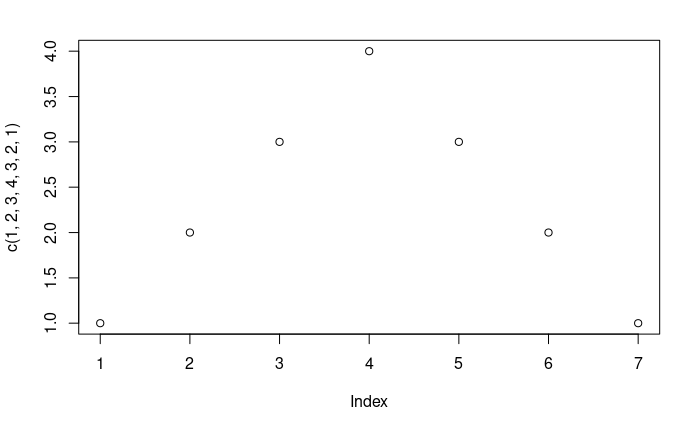

```r
plot(c(1,2,3,4,3,2,1))
```

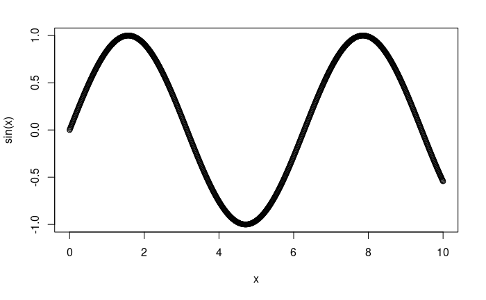

```r
x = seq(0, 10, 0.01)
plot(x, sin(x))
```

Can it be used with our `d` too?

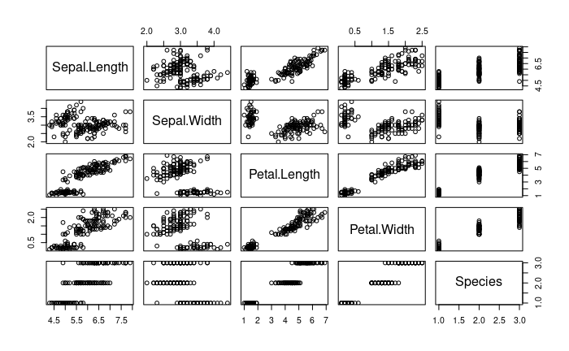

```r
plot(iris)
```

Yes, and it produces something useful. Actually really useful for our current purpose (explore the data).

Yet, serious plotting is usually done with different tools. The most common one is `ggplot`.

## Plotting with `ggplot`

`ggplot` is a *package* that itself is a member of a larger family of R packages: `tidyverse`. Install it `install.packages("tidyverse")` (not done in this notebook, may be tricky; note that you do not really need the full `tidyverse` package for doing the things we’ll do) and load it.

```r
require("tidyverse")
```

### Trivial plot with `ggplot`

*Key point*: before doing a plot, - first, *decide* what is the question the plot is going to (attempt to) answer - then, *design* the plot accordingly

Question: are the sepal length and sepal width somehow related for the species Setosa? Design: the two variables on the axes of a *scatterplot*, one point for each Setosa sample in `d`.

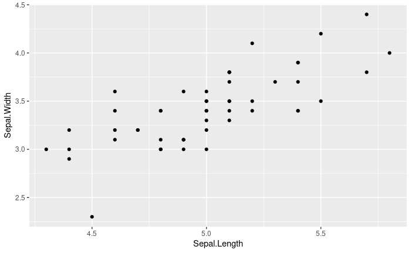

```r
d %>% filter(Species=="setosa") %>% ggplot(aes(x=Sepal.Length, y=Sepal.Width)) + geom_point()
```

New question: Is this dependency different among the three Species?

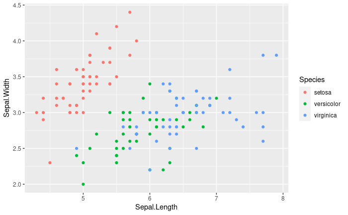

```r
d %>% ggplot(aes(x=Sepal.Length, y=Sepal.Width, color=Species)) + geom_point()
```

### Less trivial

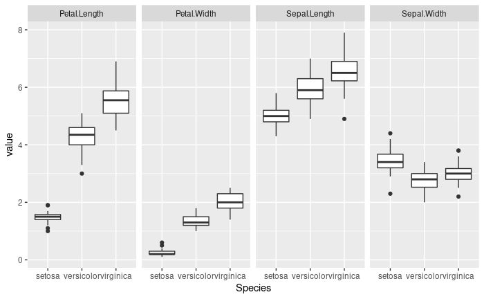

```r
d %>% pivot_longer(cols=!Species) %>% ggplot(aes(x=Species, y=value)) + geom_boxplot() + facet_grid(.~name, scales="free")
```

Maybe even better with violin-plots.

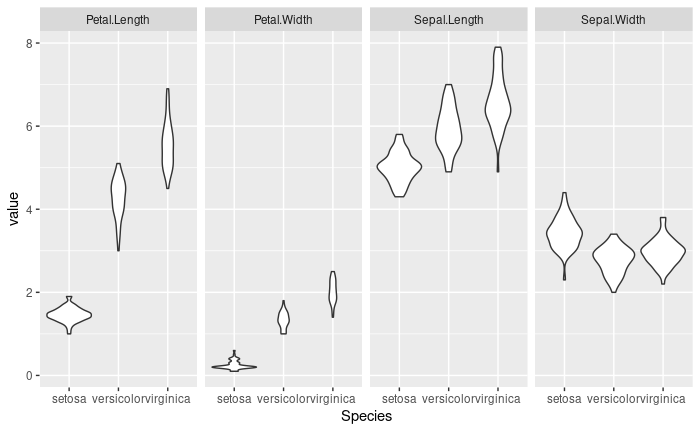

```r
d %>% pivot_longer(cols=!Species) %>% ggplot(aes(x=Species, y=value)) + geom_violin() + facet_grid(.~name, scales="free")
```

## Take-home

- Versicolor and Virginica appear harder to tell apart than Setosa.
- Petal-related attributes appear more useful (for inferring the species) than sepal- ones.